# Set_5

Alexander Williams

2024-10-02

# t-tests

examining equality of small samples.

One method we used earlier is the bootstrap test, sampling values from the small dataset to get a larger sample size. This can be used for any type of distribution

An alternative is to use a t-distribution, which makes the assumption, which assumes that the data is from a normal distribution. Other assumptions are also made on the variance of the two populations, and whether or not the two samples are independent

these assumptions lead to 3 different types of t-test

1. pooled t-test (assume equal variance between both population)
2. Welch/unpooled t-test (no assumption on equal variance)
3. paired t-test (samples are dependent, data is all in pairs)

### pooled t-test

we assume that for the first sample:
$$X_i\sim{}N(\mu_1,\sigma^2),i=1,...,m$$
and for the second:
$$Y_i\sim{}N(\mu_2,\sigma^2),i=1,...,m$$
We also assume the two samples are independent, and that $\sigma^2$ is the same in both samples.

we can put these together to get the equation:
$$\bar{X}-\bar{Y}\sim{}N(\mu_1-\mu_2,\sigma^2(\frac{1}{m}+\frac{1}{n})$$
we can rearrange this until we get:
$$\frac{\bar{X}-\bar{Y}-(\mu_1-\mu_2)}{\sigma\sqrt{\frac{1}{m}+\frac{1}{n}}}\sim{}N(0,1)$$
but what if we don’t know sigma? We can replace it with sample variance $s$. Remember that we’re assuming both have the same variance, so we calculate $s_1,s_2$, and then average them based on size of each sample.
$$s_p^2=\frac{(m-1)s_1^2+(n-1)s_2^2}{m+n-2}$$
finally, we get the equation:
$$\frac{\bar{X}-\bar{Y}-(\mu_1-\mu_2)}{s_p\sqrt{\frac{1}{m}+\frac{1}{n}}}\sim{}t_{m+n-2}$$
It’s no longer normal, but instead it’s a t distribution with $m+n-2$ degrees of freedom.

this form is recognizable, it’s the same as z-tests
$$\frac{\text{Estimate -
Parameters}}{\text{Estimate Standard Error
(ese)}}\sim{}N(0,1)$$

once we use this to get our pivotal quantity, we can proceed just like normal to determine our critical values. The only difference is that we will use the distribution $t_{m+n-2, \alpha}$ instead of $Z_\alpha$

to get our confidence interval, we use the equation:
$$(\bar{X}-\bar{Y})\pm{}t_{m+n-2,
\alpha/2}s_p\sqrt{\frac{1}{m}+\frac{1}{n}}$$

# Example: latent heat

two methods, A and B, are used to determine latent heat of fusion of ice. We want to know if the two methods differ, and by how much.

```r
ice <- read.table(file='~/Documents/uni/STAT359/data/latent_heat.txt',
                  sep="",
                  header=TRUE)
library(knitr)
kable(ice, caption = 'Data Table')
```

Data Table

| Method_A | Method_B |
| --- | --- |
| 79.98 | 80.02 |
| 80.04 | 79.94 |
| 80.02 | 79.98 |
| 80.04 | 79.97 |
| 80.03 | 79.97 |
| 80.03 | 80.03 |
| 80.04 | 79.95 |
| 79.97 | 79.97 |
| 80.05 | NA |
| 80.03 | NA |
| 80.02 | NA |
| 80.00 | NA |
| 80.02 | NA |

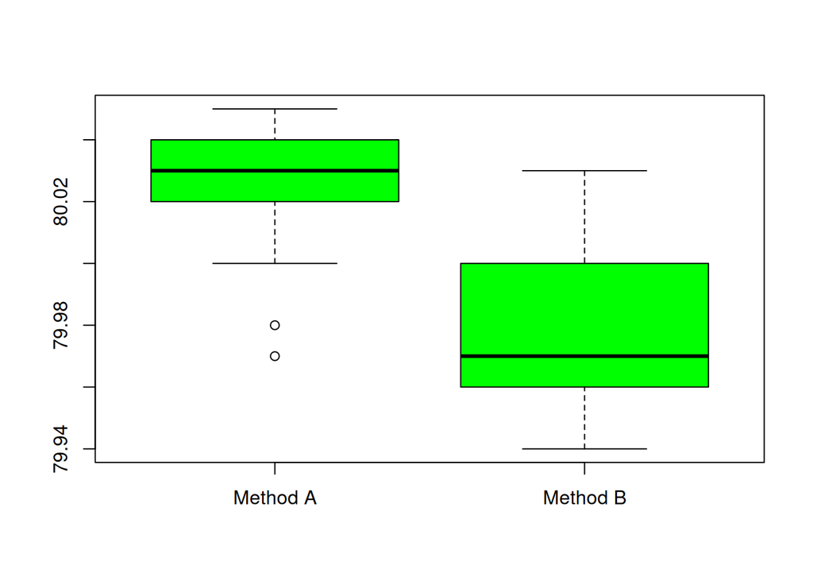

```r
# remove NA values
methodA<-ice$Method_A[!is.na(ice$Method_A)]
methodB<-ice$Method_B[!is.na(ice$Method_B)]
boxplot(methodA,methodB,names=c('Method A','Method B'),col="green")
```

The distributions seem reasonably separated, lets use the t-test

```r
t.test(methodA,
       methodB,
       alternative="two.sided", # just checking if not the same
       mu=0, # parameters, mu_1 - mu_2
       var.equal=TRUE) # assume the variances are equal
```

```
##
##  Two Sample t-test
##
## data:  methodA and methodB
## t = 3.4722, df = 19, p-value = 0.002551
## alternative hypothesis: true difference in means is not equal to 0
## 95 percent confidence interval:
##  0.01669058 0.06734788
## sample estimates:
## mean of x mean of y
##  80.02077  79.97875
```

the confidence interval does not include 0 and the p-val is less than alpha, so we have strong evidence that the null hypothesis is false. if the distributions are the same, there is only a 0.2% chance of observing data at least this extreme.

Lets look closer at the data

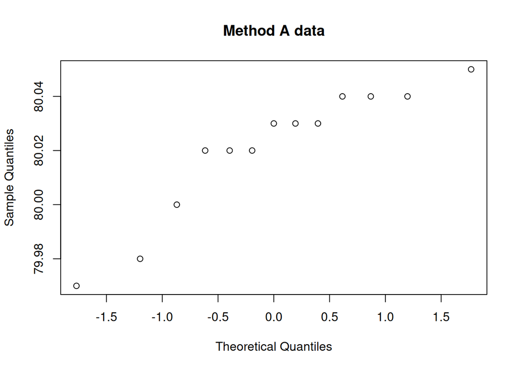

```r
qqnorm(methodA,
       main="Method A data")
```

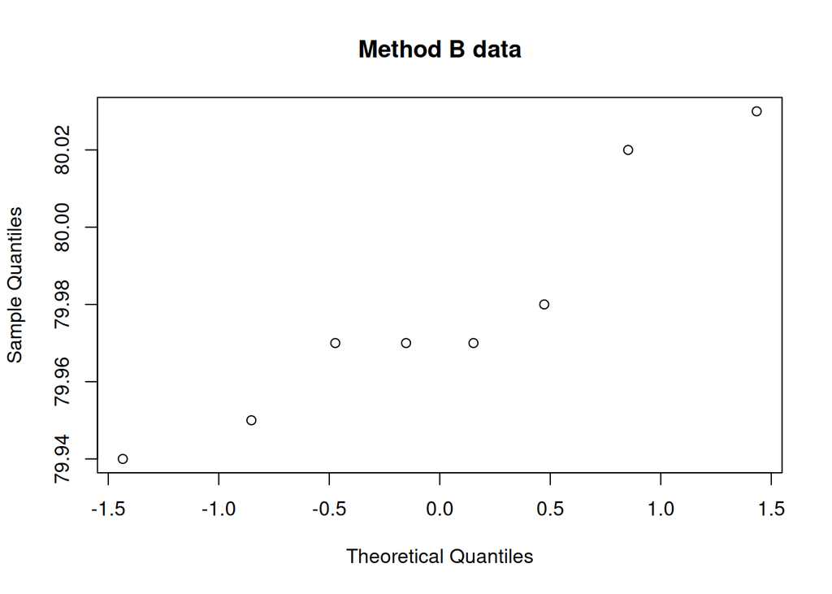

```r
qqnorm(methodB,
       main="Method B data")
```

There’s not many data points so it’s hard to come to conclusions on if the data is normal or not, or there’s not enough evidence to say the distributions are not normal.

```r
var(methodA)
```

```
## [1] 0.000574359
```

```r
var(methodB)
```

```
## [1] 0.0009839286
```

the variances do appear to be different, it may be worth testing with an unpooled t-test

```r
t.test(methodA,
       methodB,
       alternative="two.sided",
       mu=0,
       var.equal=FALSE)
```

```
##
##  Welch Two Sample t-test
##
## data:  methodA and methodB
## t = 3.2499, df = 12.027, p-value = 0.006939
## alternative hypothesis: true difference in means is not equal to 0
## 95 percent confidence interval:
##  0.01385526 0.07018320
## sample estimates:
## mean of x mean of y
##  80.02077  79.97875
```

while the p-value is larger, it’s still very unlikely that both distributions have the same mean. We have less confidence, but the p-value is still veyr small

# Example: Iron Retention

Investigators are determining if Fe2+ and Fe3+ are retained differently, to find which is better as a dietary supplement

6 group of mice, given either 10.2, 1.2, or 0.3 millimolar or either Fe2+ or Fe3+

```r
iron <- read.table(file='~/Documents/uni/STAT359/data/iron.txt',
                    sep="",
                    header=TRUE)
kable(iron, caption = 'Iron Retention Data Table')
```

Iron Retention Data Table

| Fe3 | Fe2 |
| --- | --- |
| 2.20 | 4.04 |
| 2.93 | 4.16 |
| 3.08 | 4.42 |
| 3.49 | 4.93 |
| 4.11 | 5.49 |
| 4.95 | 5.77 |
| 5.16 | 5.86 |
| 5.54 | 6.28 |
| 5.68 | 6.97 |
| 6.25 | 7.06 |
| 7.25 | 7.78 |
| 7.90 | 9.23 |
| 8.85 | 9.34 |
| 11.96 | 9.91 |
| 15.54 | 13.46 |
| 15.89 | 18.40 |
| 18.30 | 23.89 |
| 18.59 | 26.39 |

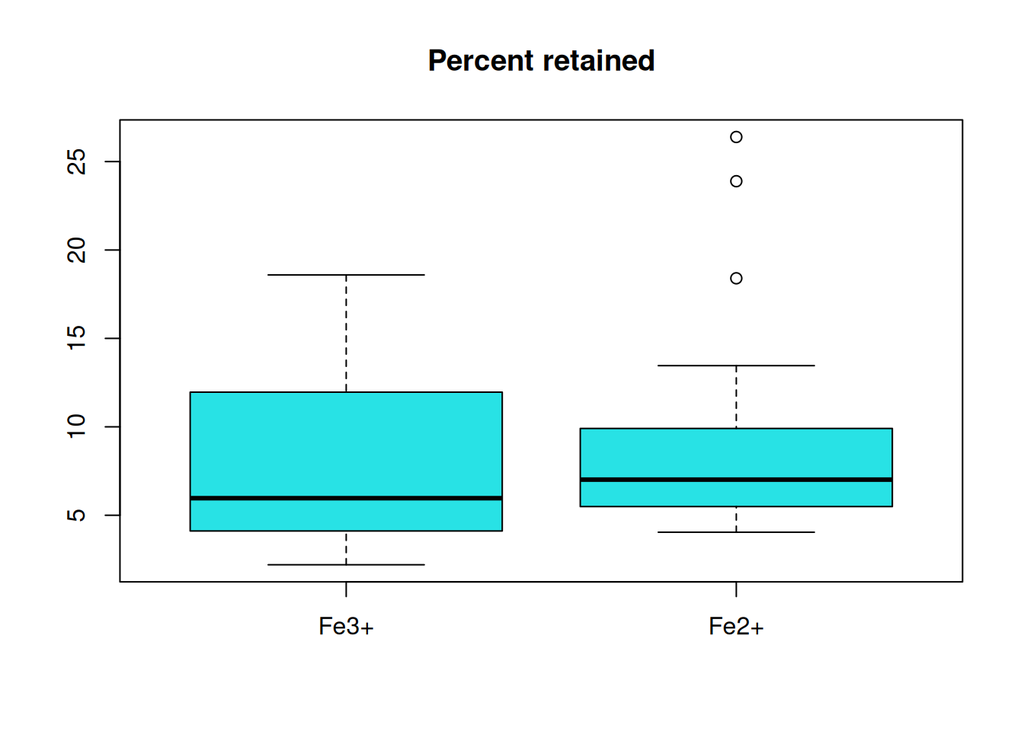

```r
boxplot(iron$Fe3,
        iron$Fe2,
        names=c("Fe3+","Fe2+"),
        main="Percent retained",
        col=5)
```

There’s a lot of overlap in these distributions. Without any analysis, it isn’t a large stretch to say the distributions are the same. Lets see if it appears normal

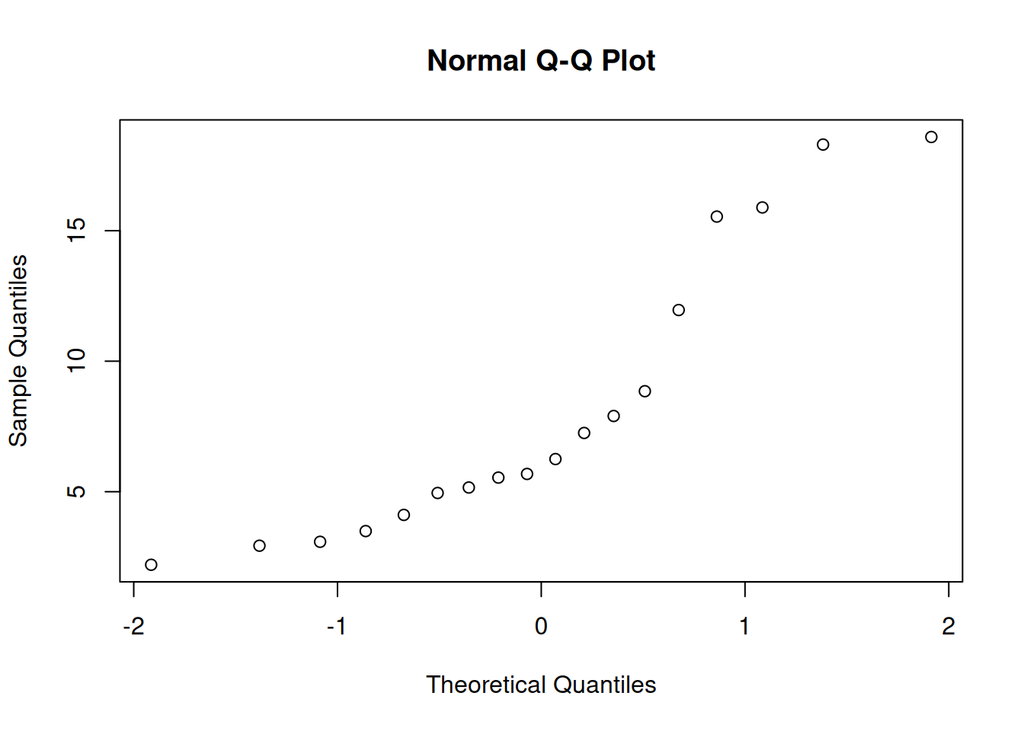

```r
qqnorm(iron$Fe3)
```

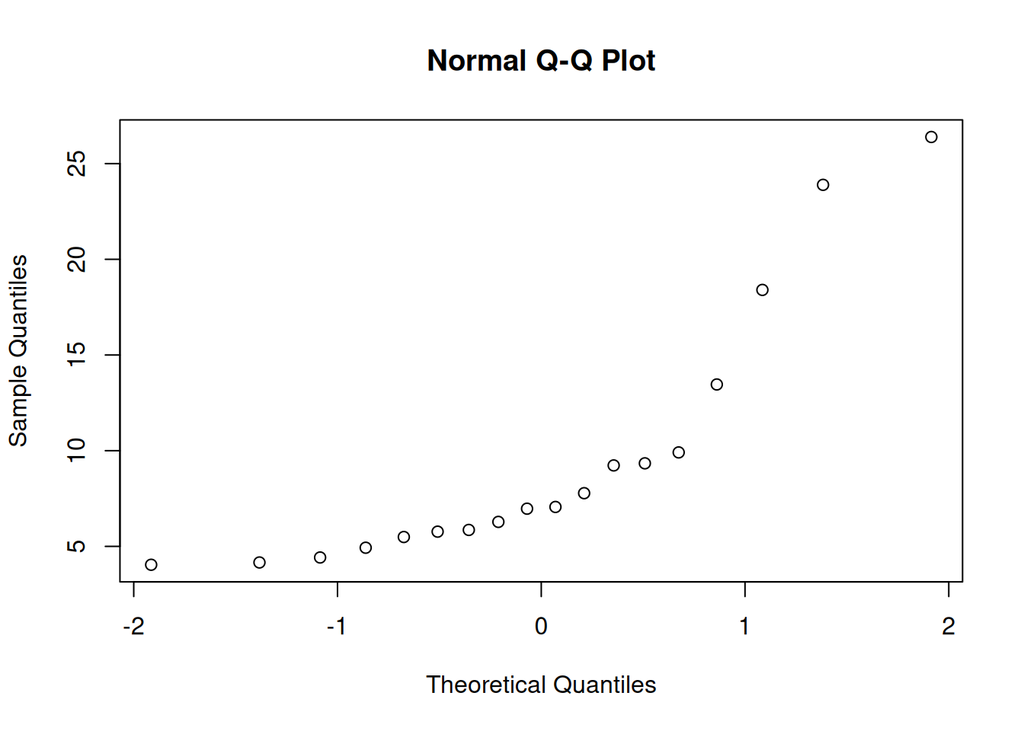

```r
qqnorm(iron$Fe2)
```

Both of these distributions appear to be skewed to the right, we can’t make the assumption of normality. We can either use a different test, or transform the data to make it symmetric.

Lets use a log transformation to make it symmetrical

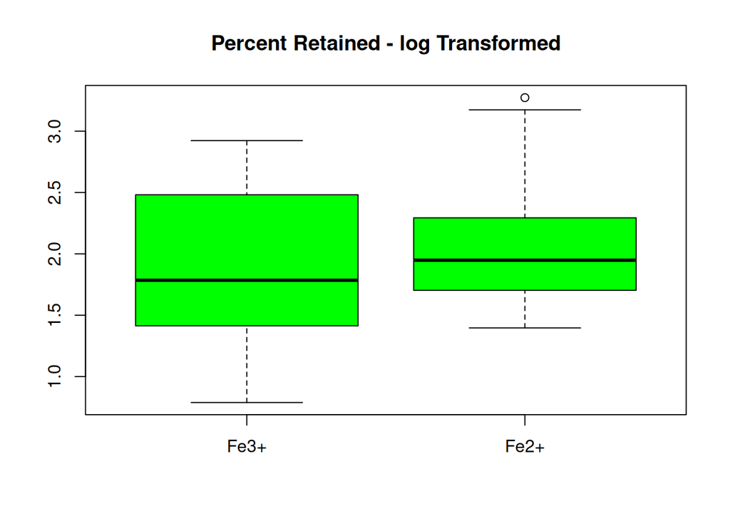

```r
boxplot(log(iron$Fe3),
        log(iron$Fe2),
        names=c('Fe3+','Fe2+'),
        col='green',
        main='Percent Retained - log Transformed')
```

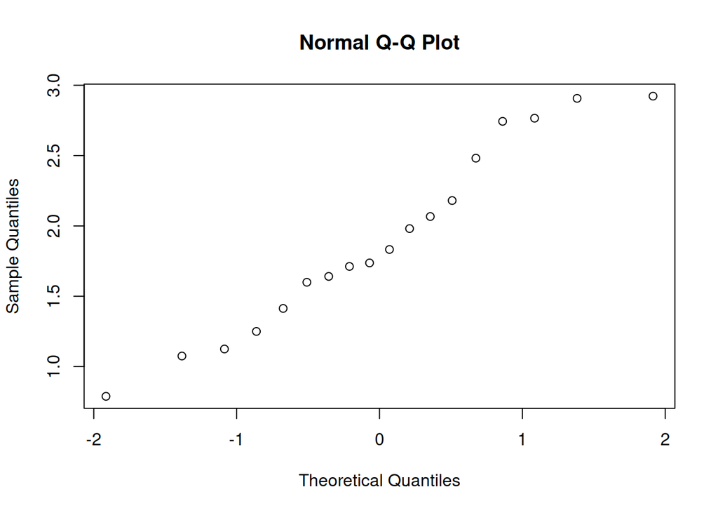

```r
qqnorm(log(iron$Fe3))
```

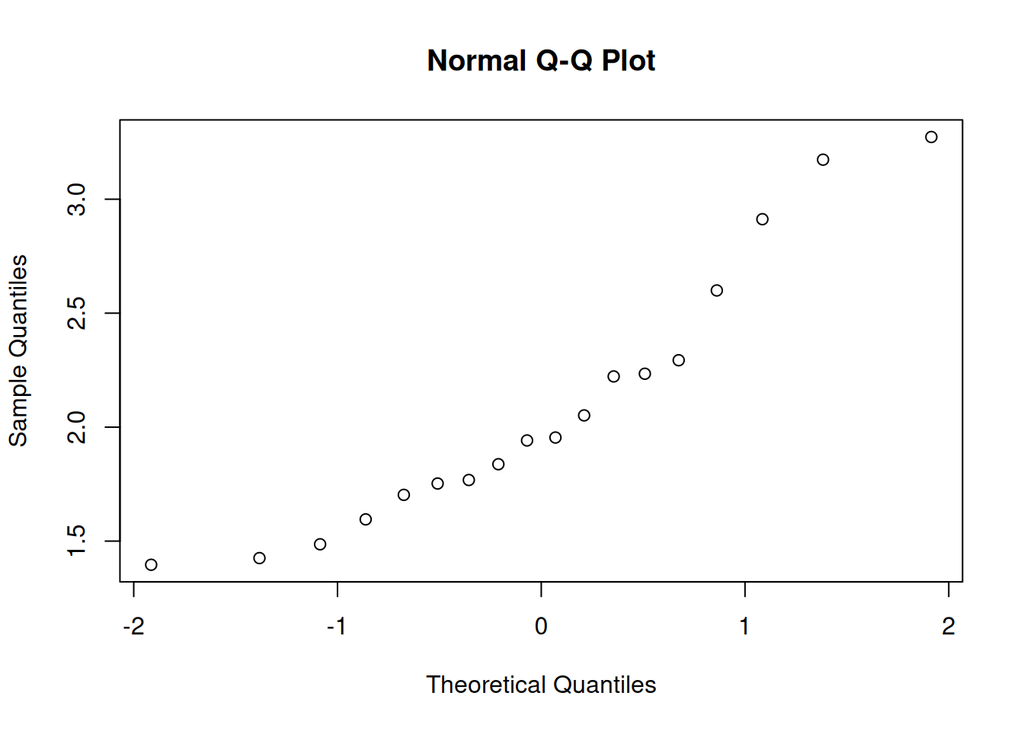

```r
qqnorm(log(iron$Fe2))
```

Still a large amount of overlap on the box plots, and the data looks a lot more normal. We can run a t-test om this data

```r
t.test(log(iron$Fe3),
       log(iron$Fe2),
       alternative="two.sided",
       mu=0,
       var.equal=TRUE)
```

```
##
##  Two Sample t-test
##
## data:  log(iron$Fe3) and log(iron$Fe2)
## t = -0.91728, df = 34, p-value = 0.3655
## alternative hypothesis: true difference in means is not equal to 0
## 95 percent confidence interval:
##  -0.6071510  0.2295115
## sample estimates:
## mean of x mean of y
##  1.901225  2.090045
```

As we expected earlier, the p-value is large. Assuming they’re the same, about 36% of the time we’d expect a difference at least this extreme. There is no evidence to reject the null hypothesis. Do remember, this was done on the log scale.

### How do we decide whether or not to use a pooled t-test?

one options is to use a test for variance, to decide if we should use pooled or unpooled.

This test is based off of the F-distribution. Let $X\sim\chi_m^2$ and $Y\sim\chi_n^2$. Let X and Y be independent random variables.

the $F_{m,n}$ distribution is defined as: $Z=\frac{X/m}{Y/n}$ .

Lets graph this distribution

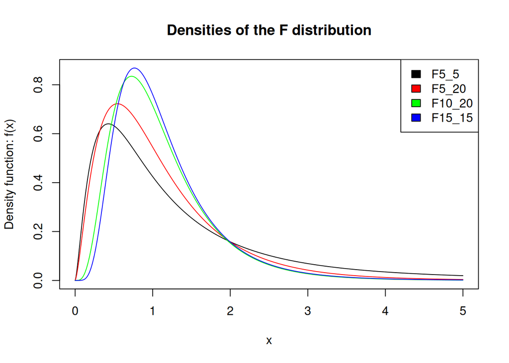

```r
x <-seq(0,5,0.01)

dF5_5<-df(x,df1=5,df2=5) # input values, and the two degrees of freedom
dF5_20<-df(x,df1=5,df2=20)
dF10_20<-df(x,df1=10,df2=20)
dF15_15<-df(x,df1=15,df2=15)

plot(c(min(x),
       max(x)),
     c(min(dF5_5,dF5_20,dF10_20,dF15_15),
       max(dF5_5,dF5_20,dF10_20,dF15_15)),
     type="n",
xlab="x",ylab="Density function: f(x)")
title("Densities of the F distribution")
lines(x,dF5_5)
lines(x,dF5_20,col="red")
lines(x,dF10_20,col="green")
lines(x,dF15_15,col="blue")
legend(x='topright',
       legend=c('F5_5','F5_20','F10_20','F15_15'),
       fill=c('black','red','green','blue'))
```

The F-test for $H_0: \sigma_1^2=\sigma_2^2$ is based on:
$$T=\frac{max\{s_1^2, s_2^2\}}{min\{s_1^2,
s_2^2\}}$$
Just divide the bigger sample distribution by the smaller one, and we get a test statistic just like we do when using a t-test or z-test

When getting confidence intervals, we use a $F_{m-1,n-1}$ distribution

# Example: Latent Heat

Same dataset as earlier

```r
kable(ice)
```

| Method_A | Method_B |
| --- | --- |
| 79.98 | 80.02 |
| 80.04 | 79.94 |
| 80.02 | 79.98 |
| 80.04 | 79.97 |
| 80.03 | 79.97 |
| 80.03 | 80.03 |
| 80.04 | 79.95 |
| 79.97 | 79.97 |
| 80.05 | NA |
| 80.03 | NA |
| 80.02 | NA |
| 80.00 | NA |
| 80.02 | NA |

```r
var.test(methodA,methodB)
```

```
##
##  F test to compare two variances
##
## data:  methodA and methodB
## F = 0.58374, num df = 12, denom df = 7, p-value = 0.3938
## alternative hypothesis: true ratio of variances is not equal to 1
## 95 percent confidence interval:
##  0.1251097 2.1052687
## sample estimates:
## ratio of variances
##          0.5837405
```

Note this function divides smaller variance by larger variance, but that’s just a different way of doing it.

The p-value is quite large, there’s no evidence against the null hypotheses. There’s no evidence that the distributions have different variances

# Example: Iron

same dataset as earlier

```r
kable(iron)
```

| Fe3 | Fe2 |
| --- | --- |
| 2.20 | 4.04 |
| 2.93 | 4.16 |
| 3.08 | 4.42 |
| 3.49 | 4.93 |
| 4.11 | 5.49 |
| 4.95 | 5.77 |
| 5.16 | 5.86 |
| 5.54 | 6.28 |
| 5.68 | 6.97 |
| 6.25 | 7.06 |
| 7.25 | 7.78 |
| 7.90 | 9.23 |
| 8.85 | 9.34 |
| 11.96 | 9.91 |
| 15.54 | 13.46 |
| 15.89 | 18.40 |
| 18.30 | 23.89 |
| 18.59 | 26.39 |

```r
var.test(iron$Fe3, iron$Fe2)
```

```
##
##  F test to compare two variances
##
## data:  iron$Fe3 and iron$Fe2
## F = 0.66278, num df = 17, denom df = 17, p-value = 0.405
## alternative hypothesis: true ratio of variances is not equal to 1
## 95 percent confidence interval:
##  0.247924 1.771797
## sample estimates:
## ratio of variances
##          0.6627753
```

Again, we have no evidence that the two distributions have different variances